# **Zack Loken - OCS 7131 Exercise 6**

#### **1. When pooling across all lakes and years, does secchi depth increase, decrease, or not change throughout the summer months?**

```r
# Load the library that contains the lake quality data
library("adklakedata")

# Load the secchi depth data to an object named 'secchi'
secchi <- adk_data('secchi')

# (A) Consider a linear model where months are a continuous predictor.

## Simple linear regression is a suitable model; it tests for the
## effect of a continuous predictor on the response variable.

### month - continuous - predictor variable (x);
### secchi - continuous - response variable (y)

# Isolate columns into separate objects and define their data types.
month = as.numeric(secchi$month)
secchi = as.numeric(secchi$secchi)

# Define the linear model.
A1 <- lm(secchi ~ month)
A1
```

```
##
## Call:
## lm(formula = secchi ~ month)
##
## Coefficients:
## (Intercept)        month
##     5.06803     -0.07585
```

```r
# Evaluate the residuals and model fit, and any reported significance.
summary.lm(A1)
```

```
##
## Call:
## lm(formula = secchi ~ month)
##
## Residuals:
##     Min      1Q  Median      3Q     Max
## -3.6612 -1.6612 -0.4612  1.1871  9.8871
##
## Coefficients:
##             Estimate Std. Error t value Pr(>|t|)
## (Intercept)  5.06803    0.68932   7.352 4.23e-13 ***
## month       -0.07585    0.09121  -0.832    0.406
## ---
## Signif. codes:  0 '***' 0.001 '**' 0.01 '*' 0.05 '.' 0.1 ' ' 1
##
## Residual standard error: 2.231 on 943 degrees of freedom
##   (18 observations deleted due to missingness)
## Multiple R-squared:  0.0007328,  Adjusted R-squared:  -0.0003269
## F-statistic: 0.6915 on 1 and 943 DF,  p-value: 0.4059
```

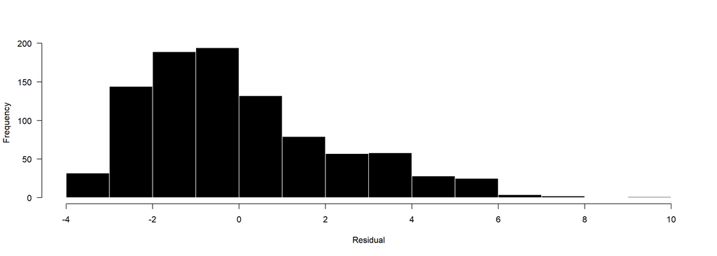

```r
# Plot the residuals to a histogram to see if they are close to being
# centered over 0 w/ roughly symmetric shape.
resA1 <- resid(A1)
hist(resA1, breaks = 10, las = 1, col = 1, border = "white", xlab = "Residual", main = '')
```

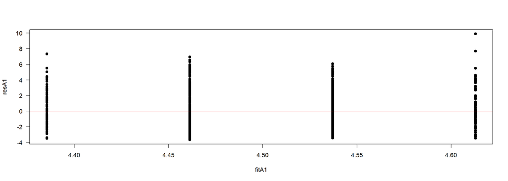

```r
# Plot the residuals as a function of the fitted data.
# Look for residuals spread evenly, and w/ symmetry, above and below 0
fitA1 <- fitted(A1)
plot(resA1 ~ fitA1, pch = 19, las = 1); abline(0, 0, col = "red")
```

##### (A). The above linear model (simple linear regression) considered month to be a continuous predictor. When pooling across all lakes and years, mean secchi depth decreases throughout the summer months. The `month` estimate of -0.0759 tells us that for every 1 unit increase in month, mean secchi depth decreases by 0.0759. The intercept was 5.068. We can conclude that water clarity does not significantly change throughout the summer because of the negative R-squared value (R-squared = -0.0003269) and a p-value > 0.05 (p = 0.406).

```r
# Load the secchi depth data to an object named 'secchi'
secchi <- adk_data('secchi')

# (B) Consider a linear model where months are a factor (categorical predictor).

## ANOVA is a suitable model; it tests for the effect of a categorical
## predictor with 3 or more groups on the response variable.

### month - categorical - predictor w/ 4 factor levels (x);
### secchi - continuous- response variable (y)

# Isolate columns into separate objects and define their data types.
month = as.factor(secchi$month)
secchi = as.numeric(secchi$secchi)

# Define the linear model.
B1 <- aov(secchi ~ month)
B1
```

```
## Call:
##    aov(formula = secchi ~ month)
##
## Terms:
##                    month Residuals
## Sum of Squares    30.273  4664.894
## Deg. of Freedom        3       941
##
## Residual standard error: 2.226517
## Estimated effects may be unbalanced
## 18 observations deleted due to missingness
```

```r
# Evaluate the residuals and model fit, and any reported significance.
summary(B1)
```

```
##              Df Sum Sq Mean Sq F value Pr(>F)
## month         3     30  10.091   2.036  0.107
## Residuals   941   4665   4.957
## 18 observations deleted due to missingness
```

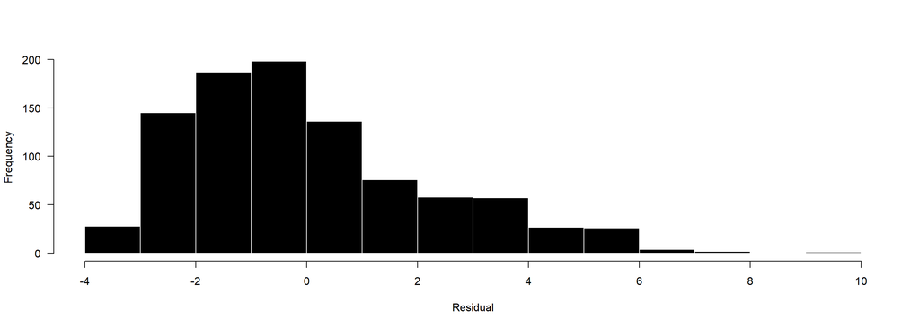

```r
# Plot the residuals to a histogram to see if they are close to being
# centered over 0 w/ roughly symmetric shape.
resB1 <- resid(B1)
hist(resB1, breaks = 10, las = 1, col = 1, border = "white", xlab = "Residual", main = '')
```

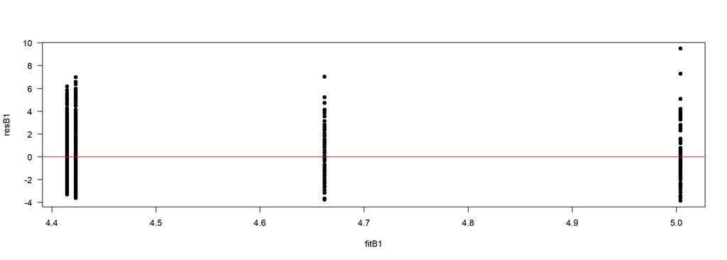

```r
# Plot the residuals as a function of the fitted data.
# Look for residuals spread evenly, and w/ symmetry, above and below 0
fitB1 <- fitted(B1)
plot(resB1 ~ fitB1, pch = 19, las = 1); abline(0, 0, col = "red")
```

#### **2. When pooling across all lakes and all months, does secchi depth increase, decrease, or not change throughout the years in the data (1994 - 2012)?**

```r
# Load the secchi depth data to an object named 'secchi'
secchi <- adk_data('secchi')

# Consider a linear model where years are a continuous predictor.

## Simple linear regression is a suitable model; it tests for the
## effect of a continuous predictor on the response variable.

### year - continuous - predictor variable (x);
### secchi - continuous - response variable (y)

# Isolate columns into separate objects and define their data types.
year = as.numeric(secchi$year)
secchi = as.numeric(secchi$secchi)

# Define the linear model.
A2 <- lm(secchi ~ year)
A2
```

```
##
## Call:
## lm(formula = secchi ~ year)
##
## Coefficients:
## (Intercept)         year
##    85.81037     -0.04063
```

```r
# Evaluate the residuals and model fit, and any reported significance.
summary.lm(A2)
```

```
##
## Call:
## lm(formula = secchi ~ year)
##
## Residuals:
##     Min      1Q  Median      3Q     Max
## -3.7031 -1.6938 -0.4219  1.0969  9.7562
##
## Coefficients:
##             Estimate Std. Error t value Pr(>|t|)
## (Intercept) 85.81037   28.18251   3.045  0.00239 **
## year        -0.04063    0.01408  -2.885  0.00400 **
## ---
## Signif. codes:  0 '***' 0.001 '**' 0.01 '*' 0.05 '.' 0.1 ' ' 1
##
## Residual standard error: 2.222 on 943 degrees of freedom
##   (18 observations deleted due to missingness)
## Multiple R-squared:  0.00875,    Adjusted R-squared:  0.007699
## F-statistic: 8.324 on 1 and 943 DF,  p-value: 0.004001
```

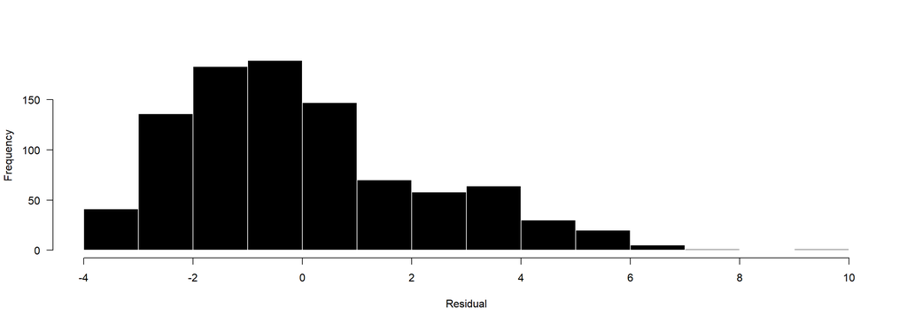

```r
# Plot the residuals to a histogram to see if they are close to being
# centered over 0 w/ roughly symmetric shape.
resA2 <- resid(A2)
hist(resA2, breaks = 10, las = 1, col = 1, border = "white", xlab = "Residual", main = '')
```

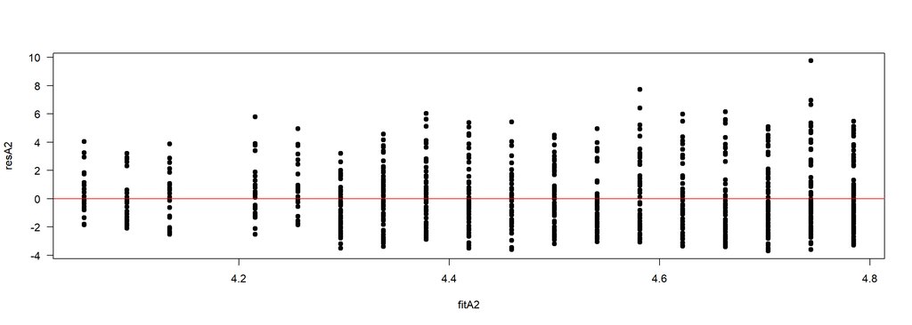

```r
# Plot the residuals as a function of the fitted data.
# Look for residuals spread evenly, and w/ symmetry, above and below 0
fitA2 <- fitted(A2)
plot(resA2 ~ fitA2, pch = 19, las = 1); abline(0, 0, col = "red")
```

##### The above linear model (simple linear regression) considered year to be a continuous predictor. When pooling across all lakes and years, mean secchi depth decreases across years. The `year` estimate of -0.0406 tells us that for every 1 unit increase in year, mean secchi depth decreases by 0.0406. The intercept was 85.810. We can conclude that water clarity significantly changes accross years (i.e., we can reject the null hypothesis) because of the p-value < 0.05 (p = 0.004), but the R-squared value of 0.0077 tells us that the predictor variable year does not account for much of the mean of the response variable secchi depth.